# GWAS-eQTL colocalization analysis workflow

Fang Li

9/11/2019

### 1. The purpose of GWAS-eQTL intergration

- Is the my variant an eQTL?
- Is the leading variant of the GWAS and eQTL signal the same?
- Is my GWAS association of interest driven by an eQTL that may indiciate a functinal mechanism?

GWAS locus that colocalized with eQTL is one of the primary and scalable signal for functional follow-up analyses.

### 2. Install R/RStudio and packages

- Install the latest version of [R](https://cran.r-project.org/) or [RStudio](https://www.rstudio.com/products/rstudio/download/).
- Install R pakage locuscomparer.
- Install R package *coloc*:  
  `if (!requireNamespace("BiocManager", quietly = TRUE))` `install.packages("BiocManager")`  
  `BiocManager::install("snpStats")`  
  `install("coloc")`

### 3. Colocalization analysis using *coloc*

- Read sample data into R:  
  You can download the examples files: [GWAS](https://github.com/fangli359/fangli359.github.io/blob/master/CAD_GWAS.txt) and [eQTL](https://github.com/fangli359/fangli359.github.io/blob/master/Artery_Coronary_v7_eQTL_PHACTR1.txt) datasets.  
  `eqtl <- read.table(file="[path to]/Artery_Coronary_v7_eQTL_PHACTR1.txt", header=T, as.is=T); head(eqtl)` `gwas <- read.table(file="[path to]/CAD_GWAS.txt", header=T, as.is=T); head(gwas)`
- Merge gwas and eqtl data sets by only shared “rs _ id”:  
  `input <- merge(eqtl, gwas, by="rs_id", all=FALSE, suffixes=c("_eqtl","gwas")` `head(input)`

  Optinal: provide suffix to differentiate data source from gwas or eqtl.
- Run *coloc* using [*coloc.abf()*](https://cran.r-project.org/web/packages/coloc/vignettes/vignette.html) fuction: `result <- coloc.abf(dataset1=list(pvalues=input$pval_nominal_gwas, type="cc", S=0.33, N=nrow(gwas)) dataset2=list(pvalues=input$pval_nominal_eqtl, type="quant", N=nrow(eqtl)), MAF=input$maf)`

  Comments: [*coloc.abf()*](https://cran.r-project.org/web/packages/coloc/vignettes/vignette.html) function needs two named lists (gwas and eqtl) that contain p-values, the type of study(“cc” for case-control studies, “quant” for quantitative traits) and sample size(N). s= the proportion of samples are cases, when type=“cc”. It also needs the minor allele frequency.
- Read out posterior probabilities for colocalization:

  H0: neither trait has a genetic association in the region

  H1/H2: only trait 1/trait 2 has a genetic association in the region

  H3: both traits are associated, but with different causal variants

  H4: both traits are associated and share a single causal variant

  A posterior probability of ≥75% is considered strong evidence of the eQTL-GWAS pair influencing both the expression and GWAS trait at a particular region.

### 4. Visualization using *locuscomparer*

- Define file names of the GWAS and eQTL data sets:  
  `gwas_fn="[path to]/CAD_GWAS.txt"`  
  `eqtl_fn="[path to]/Artery_Coronary_v7_eQTL_PHACTR1.txt"`  
  `marker_col="rs_id"`  
  `pval_col="pval_nominal"`
- Run *locuscompare* to visualize: `locuscompare(in_fn1=gwas_fn, in_fn2=eqtl_fn, title1="GWAS", title2="eQTL", marker_col1= marker_col, pval_col1=pval_col, marker_col2=marker_col, pval_col2=pval_col))`
- Results output:

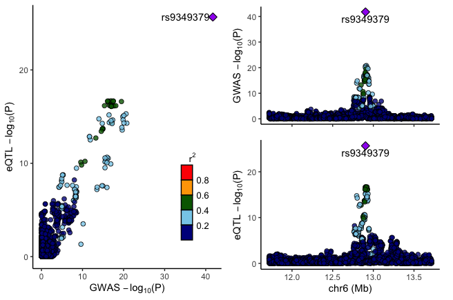